# DATA 350: Project 1 - Exploratory Data Analysis Report

Group 11: Ademir Ferreyra, Jay Nadkarni, Adrien Rozario

10/17/2025

## Introduction

From 2009 to 2012, the U.S. National Center for Health (NCHS) conducted The National Health and Nutrition Examination Survey (NHANES) with the goal of assessing public health trends, lifestyles, and illness risk factors across the U.S. population. For our exploratory data analysis, we will use the NHANESraw dataset from the NHANES R package, which was collected from the unweighted original survey responses from 20,293 participants.

The purpose of this exploratory data analysis is to better understand how socioeconomic status, lifestyle choices, and demographic factors relate to overall health and well-being. Specifically, we aim to explore the following research questions:

- How does socioeconomic status (education, poverty, home ownership, income) relate to smoking, alcohol, and drug use?
- How do lifestyle choices (smoking, alcohol, and drug use) relate to self-rated health and sleep duration?
- How do demographic factors (age, marital status, gender) influence or interact with these lifestyle and health outcomes?

Key variables of interest include:

- HHIncomeMid – midpoint of household income category (numeric)
- Education – highest education level attained (categorical)
- HomeOwn – home ownership status (categorical)
- Poverty – family poverty income ratio (numeric)
- SmokeNow, Smoke100 – indicators of smoking behavior
- Alcohol12PlusYr, AlcoholDay, AlcoholYear – measures of alcohol use
- HardDrugs – indicator of recreational drug use (if available)
- HealthGen – self-rated general health (ordinal: Excellent–Poor)
- SleepHrsNight – average hours of sleep per night (numeric)
- Age, MaritalStatus, Gender – key demographic characteristics

We expect that higher socioeconomic status is associated with lower rates of smoking and drug use, moderate alcohol consumption, and better health outcomes.

## Data Cleaning

Before conducting our exploratory analysis, we performed several data cleaning steps to ensure the quality and consistency of the NHANESraw dataset. These steps included handling missing values, converting variable types, addressing outliers, and stating key assumptions.

### Missing Value Handling

We began by examining the dataset for missing values using the summary() and colSums(is.na()) functions. Some demographic and lifestyle variables contained missing entries, especially those related to sensitive topics such as income and alcohol use. For essential demographic variables such as Gender, Age, and Education, we removed rows with missing values. For numeric variables like HHIncomeMid and SleepHrsNight, we used median imputation if the proportion of missing data was low. Variables with a high proportion of missing variables (over 50%) were excluded from the analysis.

### Type Conversions

We then standardized variable types to ensure accurate analysis. Categorical variables such as SmokeNow, Gender, Education, and HomeOwn were converted to factors. Ordinal variables like HealthGen were stored as ordered factors to preserve their natural ranking. Numeric variables such as HHIncomeMid, Poverty, and SleepHrsNight were converted to numeric types.

### Outlier Removal and Transformations

To prevent extreme values from distorting results, we visualized the distributions of key numeric variables using histograms and boxplots. Implausible outliers were removed, such as participants reporting more than 16 hours of sleep or more than 20 alcoholic drinks per day. For skewed numeric variables such as income, we applied a log transformation to normalize the distribution.

### Assumptions

During data cleaning, we made the following assumptions:

- Missing values are not related to unobserved variables.
- Median imputation provides a reasonable estimate of central tendency without introducing bias.
- Outliers identified represent data entry errors or unrealistic responses rather than meaningful population extremes.
- Ordinal variables (such as self-rated health) are consistently interpreted across respondents.
- These cleaning steps prepared the dataset for accurate and meaningful exploratory data analysis.

## Univariate Analysis

We began by exploring the distribution of individual variables to understand their distribution and potential outliers.

### Summary statistics

```
##   HHIncomeMid        Poverty        AlcoholDay     AlcoholYear
##  Min.   :  2500   Min.   :0.000   Min.   : 1.00   Min.   :  1.00
##  1st Qu.: 30000   1st Qu.:1.110   1st Qu.: 1.00   1st Qu.:  7.00
##  Median : 40000   Median :2.330   Median : 2.00   Median : 36.00
##  Mean   : 51755   Mean   :2.648   Mean   : 2.88   Mean   : 82.68
##  3rd Qu.: 87500   3rd Qu.:4.480   3rd Qu.: 3.00   3rd Qu.:104.00
##  Max.   :100000   Max.   :5.000   Max.   :20.00   Max.   :364.00
##                   NA's   :505                     NA's   :6
##  SleepHrsNight
##  Min.   : 2.000
##  1st Qu.: 6.000
##  Median : 7.000
##  Mean   : 6.817
##  3rd Qu.: 8.000
##  Max.   :12.000
##
```

These statistics provide an overview of socioeconomic and lifestyle patterns in the sample.

## Multivariate Analysis

To explore relationships between variables, we examined how socioeconomic status and lifestyle factors interact with one another and with health outcomes.

### Q1: How does socioeconomic status relate to smoking, alcohol, and drug use?

**1. Bar plot of smoking rates by education level**

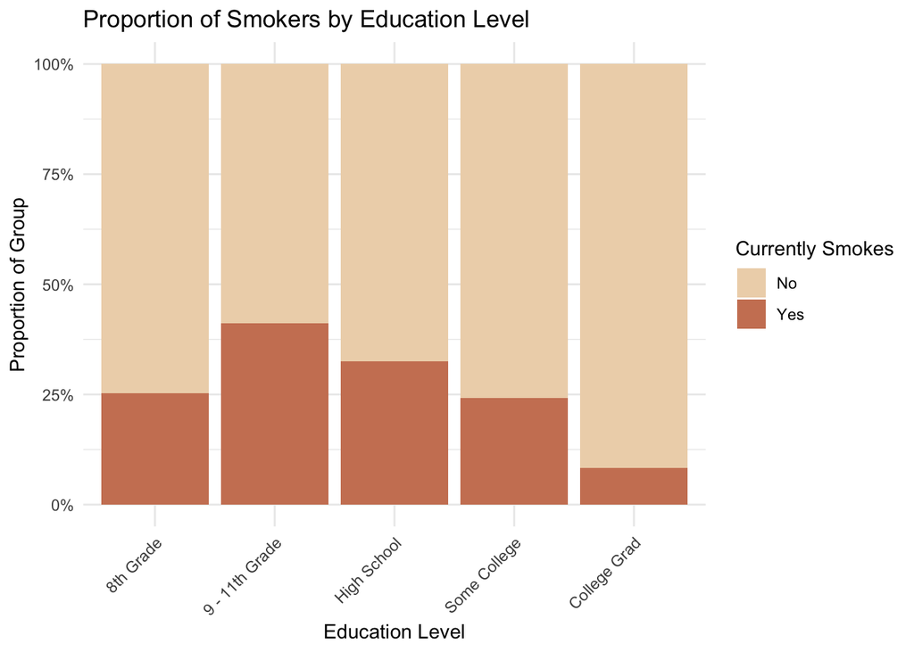

This bar plot shows that people who received 9-11th grade education are the most likely to be current smokers. This suggests that younger people are attracted to poor behaviors such as smoking. It is important to note that more than 50% of people do not smoke compared to those who do, at all education levels.

**2. Violin plot of alcohol consumption by income group**

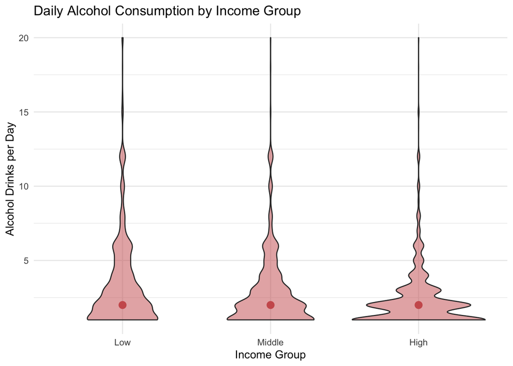

**3. Stacked bar plot of hard drug use by poverty level**

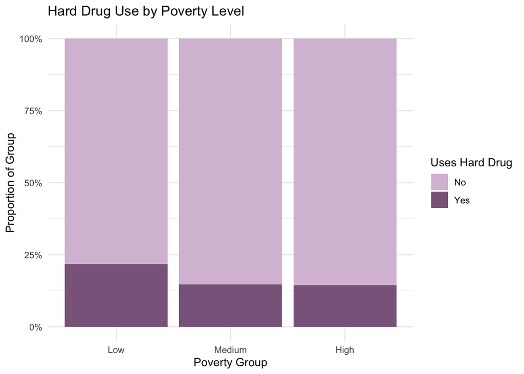

We found that lower-income groups are more than 20% likely to be consuming hard drugs based on the dataset, meaning that they are more likely to consume hard drugs such as stimulants and hallucinogens. This hints at a relationship between monetary and mental stability. The graph also reveals that most groups tend not to use hard drugs, with more than 75% of people answering that they do not consume hard drugs.

**4. Violin plot of sleep duration by smoking status**

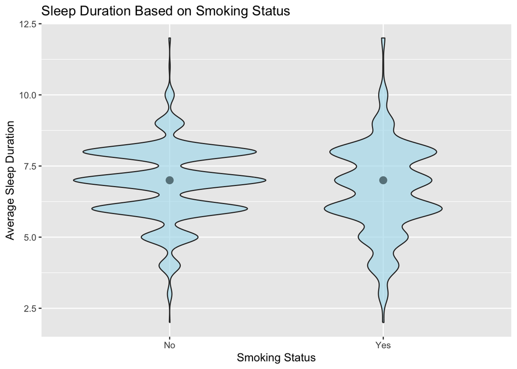

This violin plot compares hours of sleep for smokers vs. non-smokers. Both groups average around 7 hours, but the non-smokers’ more irregular, wiggly violin suggests greater variation in their sleep patterns. Smokers show a slightly tighter distribution, suggesting more regular sleep patterns. Since both violins are uneven, the data may be limited and interpretation of the results should not be considered completely accurate.

**5. Box plot of self-rated health by alcohol consumption**

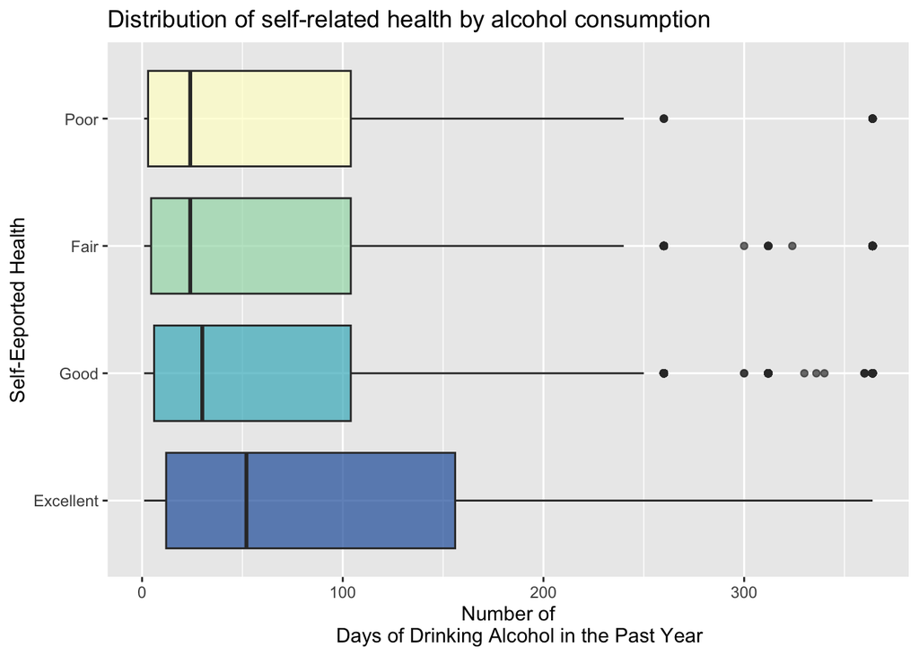

**6. Correlogram of Lifestyle Choices**

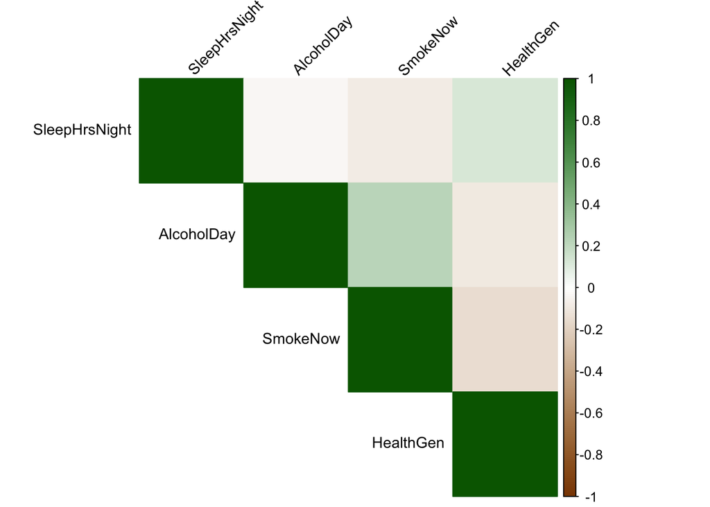

The correlgram shows that nearly all variables have very weak relationships, indicated by the pale color shading. The only noticeably positive correlation appears between alcohol consumption and smoking status, suggesting that people who drink more per day are somewhat more likely to be current smokers. A smaller positive relationship is also visible between sleep hours and general health, meaning individuals who rate their health higher tend to sleep slightly more. All other correlations are extremely close to zero, signifying little to no linear association in this subset of variables.

### Q3: How do demographic factors influence lifestyle and health outcomes?

To further explore relationships between variables, we examined how socioeconomic status and lifestyle factors interact with one another and with health outcomes.

**7. Heatmap of average daily alcohol use by age group and marital status**

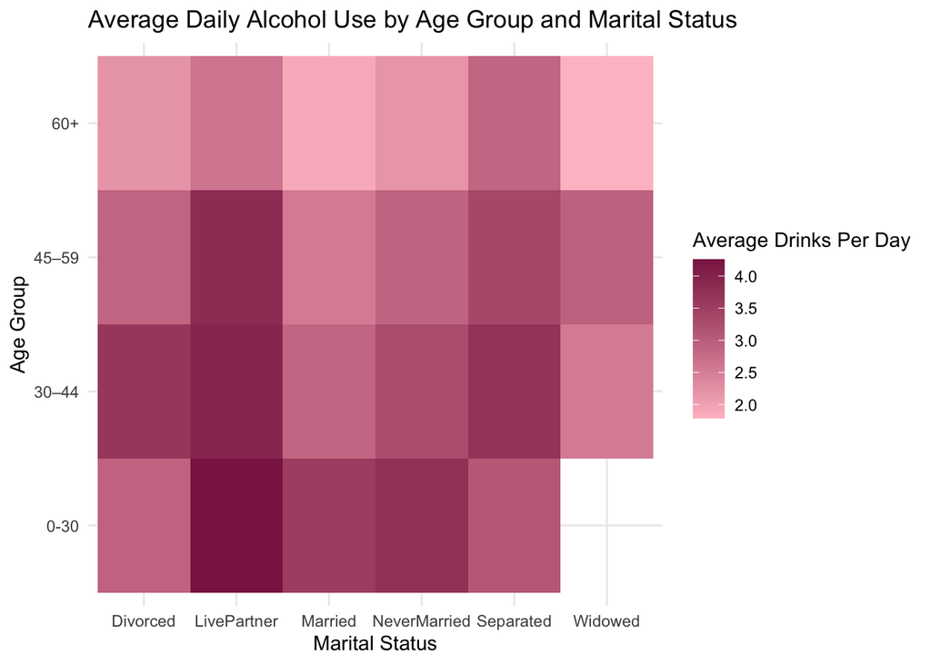

This heatmap shows a clear age-related pattern: younger adults tend to drink more alcohol per day than older adults, with the 60+ group consistently having the lowest averages. Across most age groups, individuals living with a partner report the highest alcohol intake, suggesting that relationship context may influence drinking behaviors. However, the overall differences are modest, and the heatmap mainly highlights general trends rather than strong contrasts.

**8. Faceted scatterplot (sleep duration by age, gender, and marital status)**

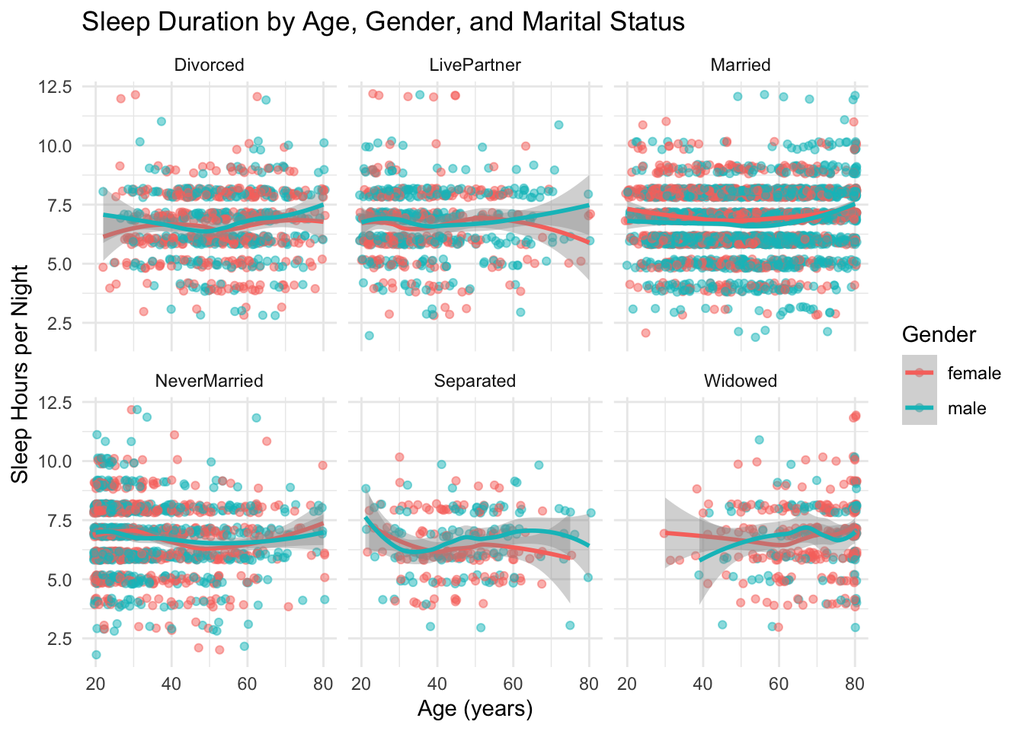

## Conclusion

Our exploratory data analysis examined how socioeconomic status, lifestyle behaviors, and demographic factors relate to health outcomes such as self-rated health and sleep duration. We observed that lower-income and lower-education individuals were more likely to engage in smoking and hard drug use, while alcohol consumption varied in ways not strictly predicted by income, suggesting the influence of social and lifestyle factors.

We found that sleep duration and self-rated health showed weak but notable relationships with lifestyle behaviors, and demographic factors such as age and marital status contributed additional variability, particularly for older adults and underrepresented marital status groups. Visualizations such as violin plots, heatmaps, and correlograms helped reveal these patterns, although uneven sample sizes and data sparsity for certain groups limit the generalizability of these findings.

Overall, our results highlight the complex connections between social, behavioral, and demographic determinants of health. While higher socioeconomic status tends to align with healthier behaviors, individual lifestyle choices and demographic contexts introduce meaningful variation. Future analyses with more recent, representative, and comprehensive datasets, combined with statistical modeling, could better portray the relationships between these variables.